# Perwalian Semester 2 | S2 Statistika Terapan FMIPA Unpad

**S2 Statistika Terapan FMIPA Unpad**Berita dan kegiatan akademik program studi Perwalian Akademik

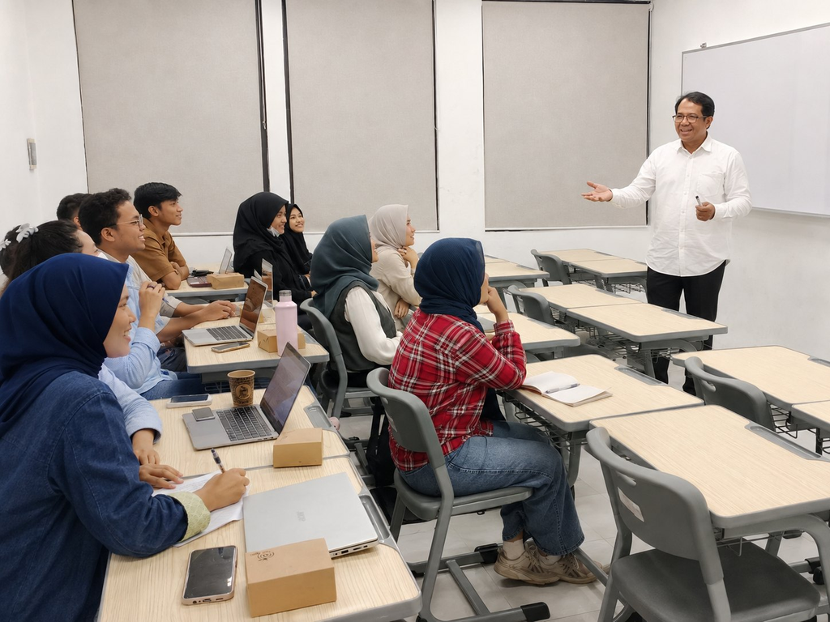

[figure not shown]

**Program Studi Magister Statistika Terapan**Fakultas Matematika dan Ilmu Pengetahuan Alam · Universitas Padjadjaran

Berita Akademik · Angkatan 2025

# Perwalian Bersama Semester 2

Pengarahan penyusunan rencana studi Semester 2 **(Genap 2025/2026)** dengan fokus pada mata kuliah pilihan dalam Kurikulum OBE 2025 berbasis *courses & research*.

Periode Akademik**Semester 2 · Genap 2025/2026**

Fokus Utama**Mata kuliah wajib dan pilihan**

Struktur Studi**18 SKS pada Semester 2**

Peserta**14 mahasiswa dan Kaprodi**

## Menyiapkan Semester 2 secara terarah

Perwalian difokuskan pada penyusunan rencana studi Semester 2, terutama pemahaman mengenai struktur mata kuliah wajib dan pemilihan mata kuliah pilihan. Mahasiswa diarahkan agar pilihan mata kuliah tidak hanya memenuhi beban studi, tetapi juga membentuk kompetensi yang konsisten dengan minat akademik, rencana tesis, serta kebutuhan profesi.

**Pokok pengarahan:** pemilihan mata kuliah perlu dirancang sebagai jalur kompetensi. Karena itu, setiap mahasiswa dianjurkan mempertimbangkan keterkaitan antara metode statistik yang dipelajari, bidang aplikasi, kesiapan data, dan arah penelitian yang akan dikembangkan.

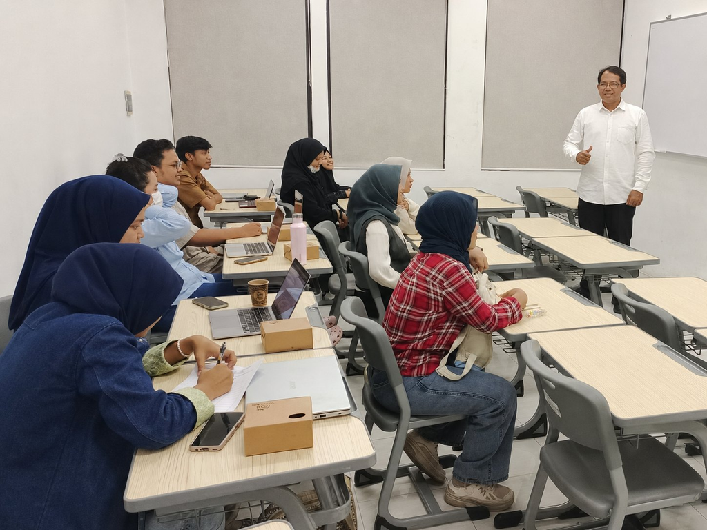

Kaprodi memberikan pengarahan mengenai perencanaan studi, beban 18 SKS, dan strategi memilih mata kuliah yang mendukung pengembangan topik penelitian.

## Materi yang dibahas

01

### Evaluasi kesiapan memasuki Semester 2

Mahasiswa meninjau perkembangan studi dan kesiapan akademik sebelum menetapkan rencana pengambilan mata kuliah.

02

### Struktur beban studi 18 SKS

Semester 2 memadukan mata kuliah wajib dan mata kuliah pilihan agar kompetensi metodologis dan bidang terapan berkembang secara seimbang.

03

### Pemilihan mata kuliah pilihan

Mahasiswa memperoleh pengarahan untuk memilih mata kuliah berdasarkan minat, bidang aplikasi, kebutuhan penelitian, dan rencana tesis.

04

### Keterkaitan *courses* dan *research*

Rencana studi diharapkan menjadi fondasi pengembangan proposal, penguasaan metode, dan penyelesaian penelitian secara terarah.

## Mata kuliah Semester 2

Dokumen struktur Kurikulum OBE 2025 menempatkan Semester 2 sebagai tahap penguatan Statistika Terapan Modern sekaligus pendalaman bidang pilihan. Beban studi yang ditampilkan adalah 18 SKS.

### Mata kuliah wajib atau inti

3 SKS · 2–1

#### Statistika Nonparametrik dan Pemodelan Fleksibel

Penguatan metode yang tidak bergantung ketat pada asumsi distribusi parametrik dan mendukung pemodelan yang lebih adaptif.

3 SKS · 2–1

#### Penambangan Data dan Kecerdasan Buatan

Pengembangan kompetensi pengolahan data, pengenalan pola, dan penerapan kecerdasan buatan dalam analisis terapan.

### Pilihan mata kuliah yang tersedia

01

#### Pemodelan Persamaan Struktural

Pemodelan hubungan laten dan jalur kausal dalam penelitian terapan.

02

#### Analisis Spasial

Analisis data yang memiliki dependensi dan struktur geografis.

03

#### Analisis Multilevel dan Longitudinal

Pemodelan data bertingkat serta pengamatan berulang dari waktu ke waktu.

04

#### Model Linear Generalisasi

Pengembangan regresi untuk respons nonnormal melalui fungsi penghubung.

05

#### Matematika Keuangan

Landasan kuantitatif untuk valuasi dan keputusan finansial.

06

#### Desain Eksperimen

Perancangan eksperimen yang efisien, terkontrol, dan dapat dipertanggungjawabkan.

07

#### Teori Antrian

Pemodelan sistem layanan, waktu tunggu, dan kapasitas operasional.

08

#### Matematika Aktuaria 1

Konsep kuantitatif dasar dalam pengukuran risiko aktuaria.

09

#### Matematika Aktuaria 2

Pendalaman model aktuaria dan perhitungan risiko lanjutan.

10

#### Analisis Survival

Pemodelan waktu hingga kejadian dengan data tersensor.

11

#### Teori Risiko

Model probabilistik untuk risiko dan kerugian.

12

#### Epidemiologi

Penerapan metode kuantitatif pada masalah kesehatan populasi.

**Catatan:** deskripsi singkat di atas digunakan sebagai panduan orientasi saat perwalian. Penetapan mata kuliah dan rincian pembelajaran tetap mengikuti dokumen kurikulum, RPS, dan ketentuan akademik Program Studi.

## Prinsip memilih mata kuliah pilihan

✓

**Selaras dengan minat dan rencana tesis**Pilih metode yang berpotensi menjadi perangkat analisis utama dalam penelitian.

✓

**Membentuk kombinasi kompetensi yang koheren**Gabungkan mata kuliah metodologis dan bidang aplikasi, bukan memilih secara terpisah tanpa arah.

✓

**Memperhatikan prasyarat dan beban kerja**Pertimbangkan kesiapan matematika, komputasi, tugas proyek, serta distribusi beban selama satu semester.

✓

**Mendukung profil profesional**Arahkan pilihan pada kompetensi yang dibutuhkan di bidang sains data, kesehatan, bisnis dan industri, sosial, atau aktuaria.

Melalui perwalian bersama ini, mahasiswa diharapkan memiliki rencana studi yang realistis, terukur, dan terhubung dengan agenda penelitian. Pemilihan mata kuliah bukan sekadar mengisi KRS—ia adalah investasi metodologis untuk tesis dan karier akademik-profesional. 🎓

Dipimpin oleh

I Gede Nyoman Mindra Jaya

Ketua Program Studi Magister Statistika Terapan FMIPA Unpad

Pengarahan menekankan ketepatan perencanaan studi, relevansi mata kuliah pilihan, dan keterhubungan pembelajaran dengan arah penelitian mahasiswa.

### Mahasiswa yang hadir

- ESEga Saherti
- SASalwa Azzah Imtiyaz
- SYSri Yuliana
- MPMahdayani Putri Yunizar
- LALinda Apriliana
- KAKiki Amelia
- APAngga Pratama
- AHAndrew Hosea Talakua
- RRRaihanah Rafidah
- AAAuro Aurellia Simbolon
- MMMelly Mustikasari
- RARana Aribah
- FOFellita Odelia Wibowo
- HKHanifah Khairunnisa

14 mahasiswa · 1 Ketua Program Studi

Dokumentasi dan Materi

## Perwalian Semester 2

Dokumentasi kegiatan luring serta materi Kurikulum OBE 2025 yang digunakan untuk menjelaskan struktur mata kuliah Semester 2.

Dokumen kurikulum tersedia melalui halaman dokumen akademik Program Studi.

Kurikulum OBE 2025 berbasis *courses & research*.

Struktur 18 SKS Semester 2 yang memadukan mata kuliah wajib dan pilihan.

[figure not shown]